# Appendix

# 6 SARIMA Modeling

## 6.1 SARIMA model for new data

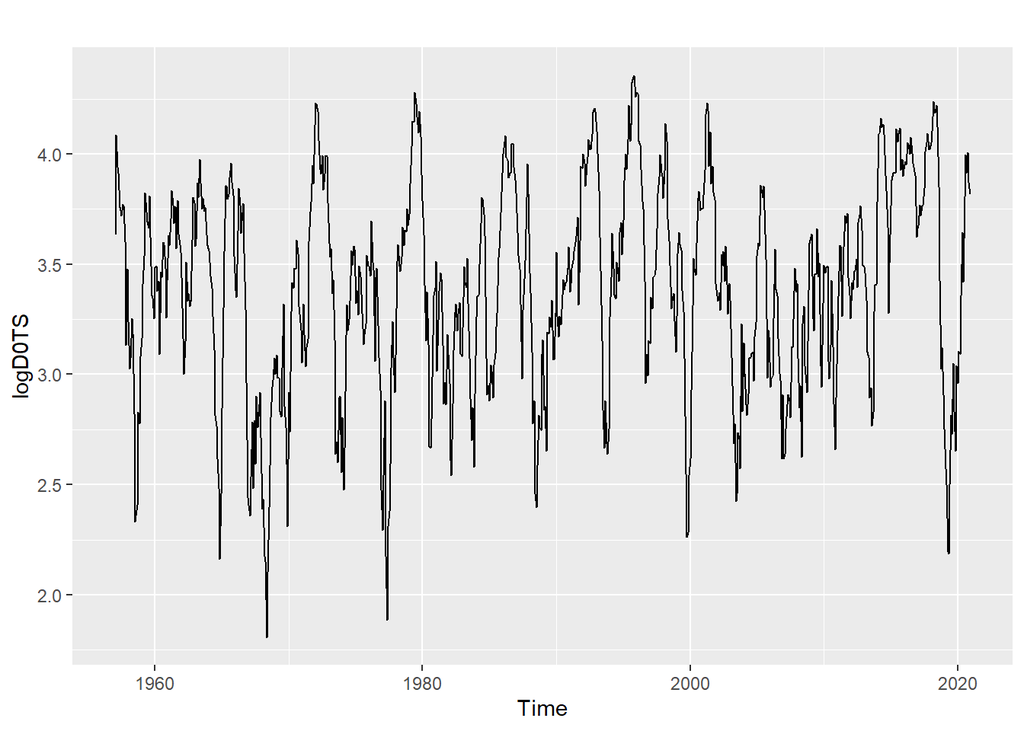

```r
log <- window(train_2022,start=c(1957,1), freq=12)
logD0TS <- log(log)
autoplot(logD0TS)
```

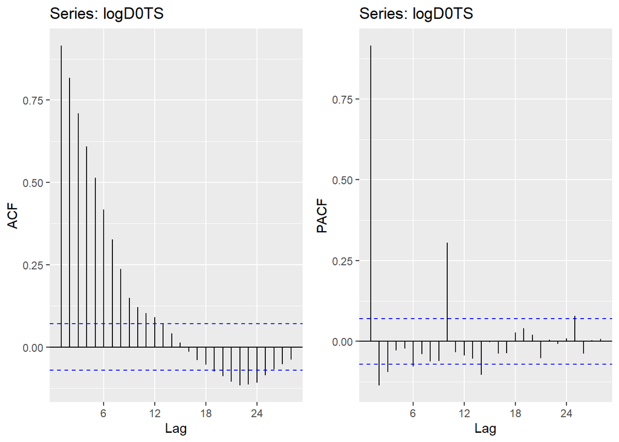

```r
grid.arrange(ggAcf(logD0TS),ggPacf(logD0TS),nrow=1)
```

```r
adf.test(logD0TS)
```

```
##
##  Augmented Dickey-Fuller Test
##
## data:  logD0TS
## Dickey-Fuller = -5.442, Lag order = 9, p-value = 0.01
## alternative hypothesis: stationary
```

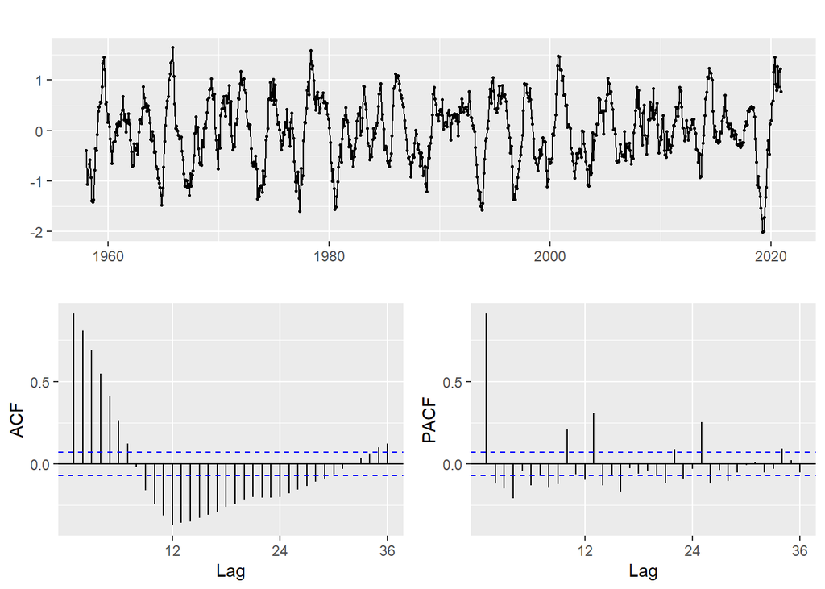

```r
datalog1 <- logD0TS %>% diff(lag=12)
datalog1 %>% ggtsdisplay()
```

```r
adf.test(datalog1)
```

```
##
##  Augmented Dickey-Fuller Test
##
## data:  datalog1
## Dickey-Fuller = -8.3754, Lag order = 9, p-value = 0.01
## alternative hypothesis: stationary
```

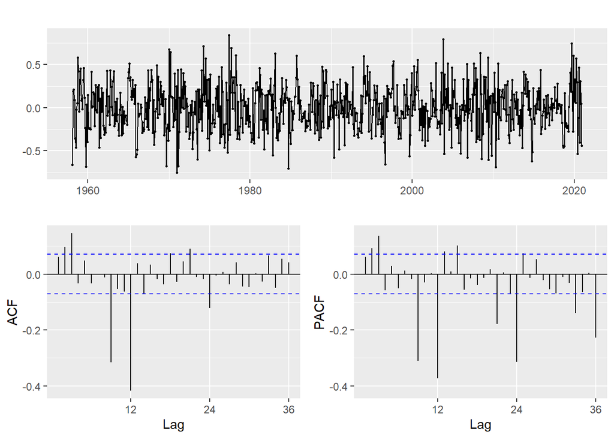

```r
datalog2 <- logD0TS %>% diff(lag=12) %>% diff()
datalog2 %>% ggtsdisplay()
```

```r
adf.test(datalog2)
```

```
##
##  Augmented Dickey-Fuller Test
##
## data:  datalog2
## Dickey-Fuller = -11.425, Lag order = 9, p-value = 0.01
## alternative hypothesis: stationary
```

```r
log1 <- Arima(logD0TS, order=c(2, 0, 1), seasonal=c(2,0,0))
log2 <- Arima(logD0TS, order=c(1, 0, 1), seasonal=c(1,0,0))
log3 <- Arima(logD0TS, order=c(2, 0, 1), seasonal=c(1,0,0))
log4 <- Arima(logD0TS, order=c(1, 0, 2), seasonal=c(1,0,0))
log5 <- Arima(logD0TS, order=c(2, 0, 2), seasonal=c(1,0,0))
log6 <- Arima(logD0TS, order=c(1, 0, 1), seasonal=c(1,0,1))
log7 <- Arima(logD0TS, order=c(2, 0, 1), seasonal=c(1,0,1))
log8 <- Arima(logD0TS, order=c(1, 0, 2), seasonal=c(1,0,1))
log9 <- Arima(logD0TS, order=c(2, 0, 2), seasonal=c(1,0,1))
log10 <- Arima(logD0TS, order=c(1, 0, 1), seasonal=c(2,0,1))
log11 <- Arima(logD0TS, order=c(2, 0, 1), seasonal=c(2,0,1))
log12 <- Arima(logD0TS, order=c(1, 0, 2), seasonal=c(2,0,1))
log12 <- Arima(logD0TS, order=c(2, 0, 2), seasonal=c(2,0,1))
```

```r
getAIC <- function(fit) {
  c(fit$aic, fit$aicc, fit$bic)
}

tab <- rbind(getAIC(log1), getAIC(log2), getAIC(log3),getAIC(log4), getAIC(log5), getAIC(log6), getAIC(log7), getAIC(log8), getAIC(log9), getAIC(log10), getAIC(log11), getAIC(log12))
colnames(tab) <- c("AIC", "AICc", "BIC")
rownames(tab) <- c("SARIMA(2,0,1)(2,0,0)","SARIMA(1,0,1)(1,0,0)","SARIMA(2,0,1)(1,0,0)","SARIMA(1,0,2)(1,0,0)",
                   "SARIMA(2,0,2)(1,0,0)","SARIMA(1,0,1)(1,0,1)","SARIMA(2,0,1)(1,0,1)","SARIMA(1,0,2)(1,0,1)",
                   "SARIMA(2,0,2)(1,0,1)","SARIMA(1,0,1)(2,0,1)","SARIMA(1,0,2)(2,0,1)","SARIMA(2,0,2)(2,0,1)")
```

```r
tab %>% kableExtra::kbl()%>%
  kable_material(c("striped", "hover"))
```

[output not shown]

```r
log1
```

```
## Series: logD0TS
## ARIMA(2,0,1)(2,0,0)[12] with non-zero mean
##
## Coefficients:
##          ar1      ar2      ma1    sar1     sar2    mean
##       1.7288  -0.7664  -0.7174  0.0826  -0.1025  3.3879
## s.e.  0.0743   0.0666   0.0875  0.0389   0.0370  0.0494
##
## sigma^2 = 0.03483:  log likelihood = 201.37
## AIC=-388.75   AICc=-388.6   BIC=-356.24
```

$$Y_t(1+\phi_1B)(1+\phi_2B)(1+\Phi_1B^{12})(1+\Phi_2B^{12})= \varepsilon_t(1+\theta_1B)$$
$$Y_t(1+\phi_1B+\phi_2B+\phi_1\phi_2B^2)(1+\Phi_1B^{12}+\Phi_2B^{12}+\Phi_1\Phi_2B^{24})= \varepsilon_t(1+\theta_1B)$$
$$Y_t(1+(\Phi_1+\Phi_2)B^{12}+\Phi_1\Phi_1B^{24}+\phi_1\phi_1B^2+\phi_1\phi_2\Phi_1\Phi_2B^{26}+\phi_1\phi_2(\Phi_1+\Phi_2)B^{14}+ (\phi_1+\phi_2)B+\Phi_1\Phi_2(\phi_1+\phi_2)B^{25}+(\Phi_1+\Phi_2)(\phi_1+\phi_2)B^{13})= \varepsilon_t(1+\theta_1B)$$
$$Y_t = (\phi_1+\phi_2)Y_{t-1} + \phi_1\phi_2Y_{t-2} + (\Phi_1+\Phi_2)Y_{t-12} + (\phi_1+\phi_2)(\Phi_1+\Phi_2)Y_{t-13} + \phi_1\phi_2(\Phi_1+\Phi_2)Y_{t-14} + \Phi_1\Phi_2Y_{t-24} + \Phi_1\Phi_2(\phi_1+\phi_2)Y_{t-25} + \Phi_1\Phi_2\phi_1\phi_2Y_{t-26}+ \varepsilon_t + \theta_1\varepsilon_{t-1}$$
$$Y_t = 0.962Y_{t-1} -1.325Y_{t-2} -0.02Y_{t-12} -0.019Y_{t-13} + 0.026Y_{t-14} -0.008Y_{t-24} -0.008Y_{t-25} + 0.011Y_{t-26}+ \varepsilon_t -0.717\varepsilon_{t-1}$$

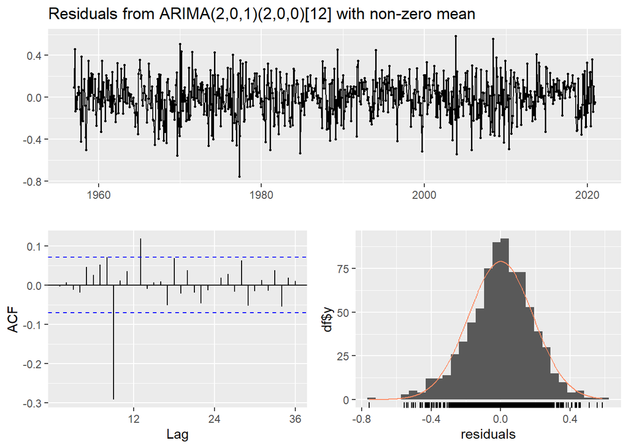

```
##
##  Ljung-Box test
##
## data:  Residuals from ARIMA(2,0,1)(2,0,0)[12] with non-zero mean
## Q* = 96.724, df = 18, p-value = 8.784e-13
##
## Model df: 6.   Total lags used: 24
```

```r
checkresiduals(log1)
```

```r
Box.test(residuals(log1), lag=4, type="Ljung-Box", fitdf=1)
```

```
##
##  Box-Ljung test
##
## data:  residuals(log1)
## X-squared = 0.44649, df = 3, p-value = 0.9305
```

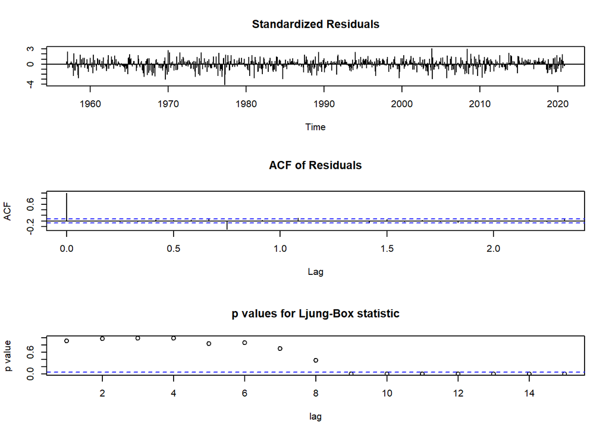

```r
tsdiag(log1, gof.lag = 15, omit.initial=F)
```

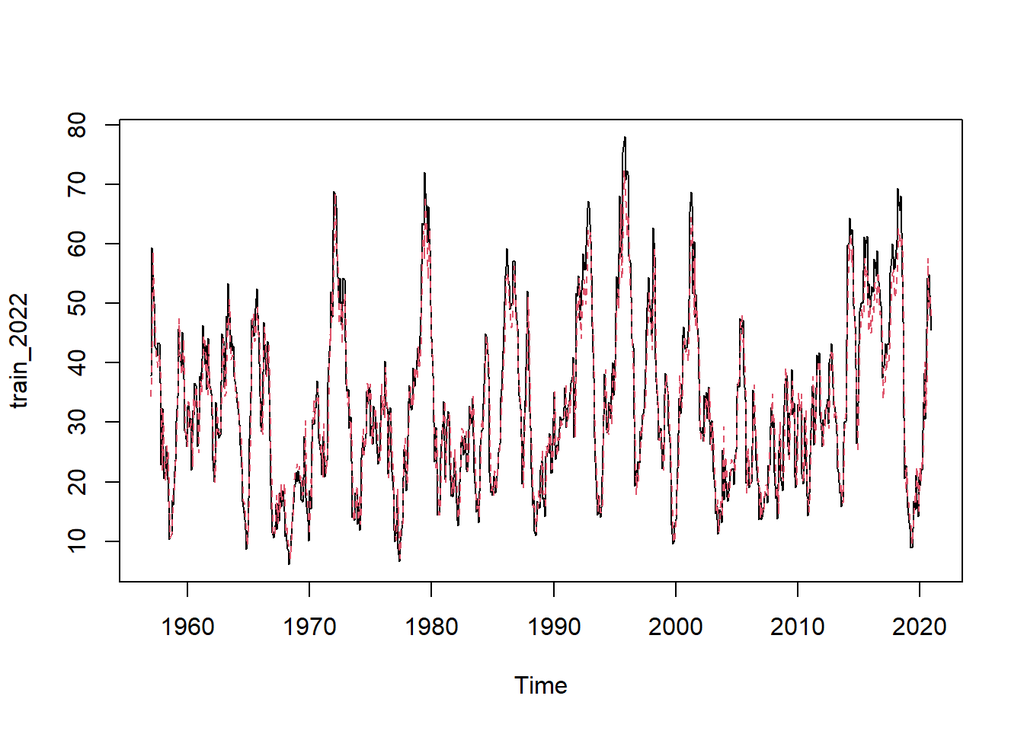

```
## integer(0)
```

```r
residualslog <- residuals(log1)
fittedlog <- logD0TS - residualslog
ts.plot(train_2022) + points(exp(fittedlog), type = "l", col = 2, lty = 2)
```

```r
forecastlog <- forecast(log1, h=15)
forecastlog$lower <- exp(forecastlog$lower)
forecastlog$upper <- exp(forecastlog$upper)
forecastlog$mean <- exp(forecastlog$mean)
forecastlog$x <- exp(forecastlog$x)

drought.predict.test <- ts_reshape(val_2022)
drought.2022 <- drought.predict.test[1:3,c(1,3)]
drought.predict.test <- drought.predict.test[,-c(3)]
colnames(drought.predict.test)[2] <- "Actual"
drought.predict.test[13:15,] <- drought.2022

forecast.full <- cbind(forecastlog,drought.predict.test[c("Actual")])
forecast.full
```

```
##          Point Forecast    Lo 80    Hi 80    Lo 95    Hi 95 Actual
## Jan 2021       43.13632 33.96058 54.79125 29.92200 62.18643   32.0
## Feb 2021       41.84372 29.77813 58.79810 24.87095 70.39930   23.4
## Mar 2021       39.75315 26.29289 60.10420 21.12512 74.80729   29.4
## Apr 2021       39.77482 24.89371 63.55165 19.42465 81.44475   25.9
## May 2021       38.90306 23.35835 64.79261 17.83056 84.87945   21.8
## Jun 2021       35.50280 20.67467 60.96583 15.52853 81.16986   21.3
## Jul 2021       33.74954 19.22781 59.23875 14.27529 79.79039   20.7
## Aug 2021       34.14655 19.16174 60.84974 14.11270 82.61967   22.1
## Sep 2021       32.08098 17.82340 57.74372 13.05767 78.81878   24.5
## Oct 2021       32.47324 17.92878 58.81669 13.09142 80.54977   29.4
## Nov 2021       32.29452 17.76522 58.70664 12.94698 80.55437   41.0
## Dec 2021       30.63198 16.81820 55.79184 12.24431 76.63300   35.5
## Jan 2022       30.58299 16.75312 55.82955 12.18224 76.77726   40.8
## Feb 2022       29.98217 16.40283 54.80338 11.91939 75.41752   39.2
## Mar 2022       29.88982 16.34164 54.67024 11.87081 75.26031   43.4
```

```r
acc <- accuracy(forecastlog,val_2022)
acc
```

```
##                     ME     RMSE      MAE       MPE     MAPE      MASE      ACF1
## Training set 29.484492 32.76494 29.48449  87.87402 87.87402 1.8716068 0.9260799
## Test set     -4.956378 11.86539 11.15885 -26.12366 41.40788 0.7083376 0.7781849
##              Theil's U
## Training set        NA
## Test set      2.517452
```

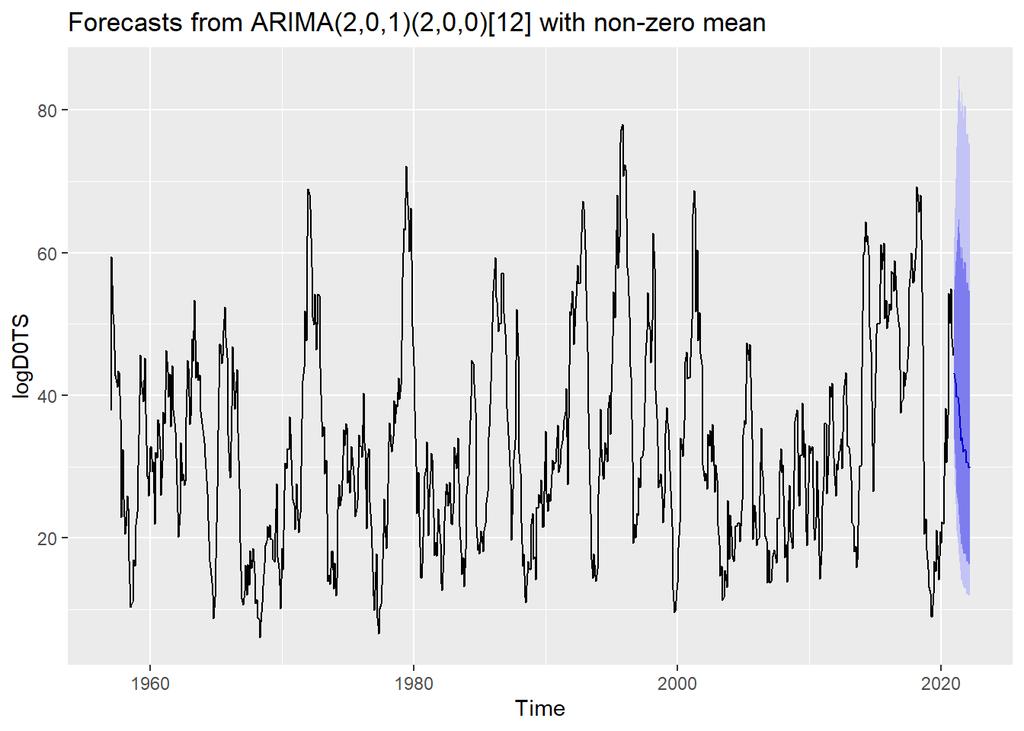

```r
autoplot(forecastlog)
```

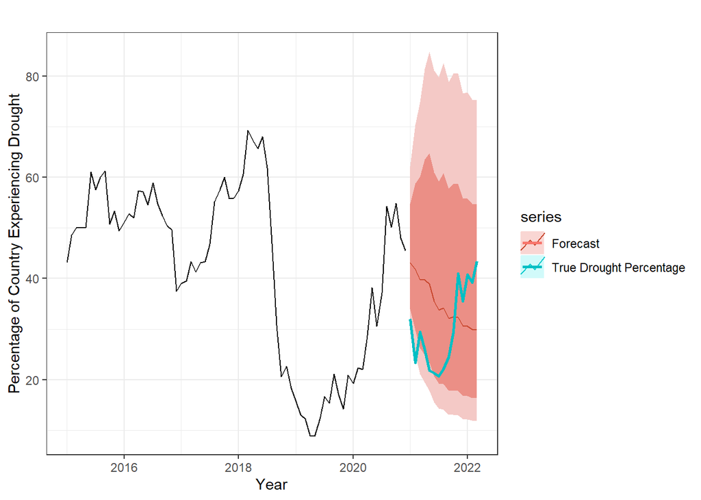

```r
autoplot(window(train_2022, start=c(2015,1))) +
  autolayer(forecastlog, PI=TRUE, series="Forecast") +
  autolayer(val_2022, series="True Drought Percentage", size=1) +
  labs(x="Year", y="Percentage of Country Experiencing Drought") +
  theme_bw()
```

```r
auto.arima(logD0TS)
```

```
## Series: logD0TS
## ARIMA(2,0,1)(2,0,0)[12] with non-zero mean
##
## Coefficients:
##          ar1      ar2      ma1    sar1     sar2    mean
##       1.7288  -0.7664  -0.7174  0.0826  -0.1025  3.3879
## s.e.  0.0743   0.0666   0.0875  0.0389   0.0370  0.0494
##
## sigma^2 = 0.03483:  log likelihood = 201.37
## AIC=-388.75   AICc=-388.6   BIC=-356.24
```

## 6.2 SARIMA modeling for old data

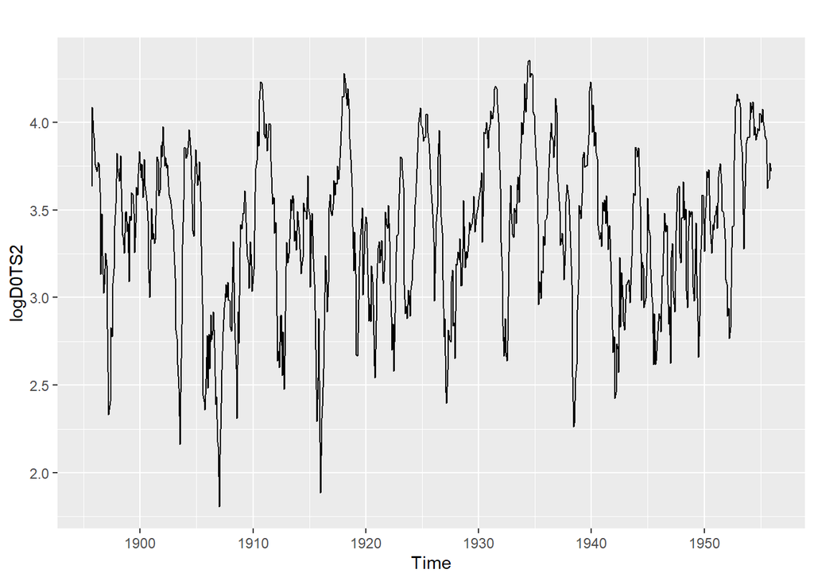

```r
log2 <- window(train_1956,start=c(1895, 9), freq=12)
logD0TS2 <- log(log2)
autoplot(logD0TS2)
```

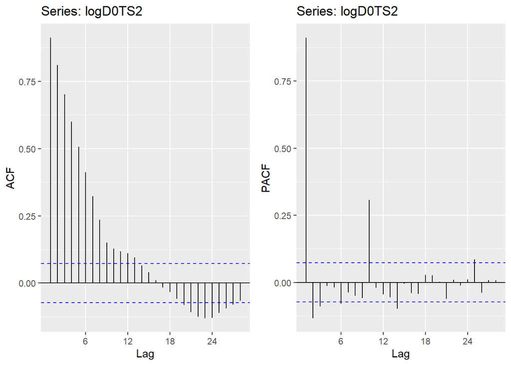

```r
grid.arrange(ggAcf(logD0TS2),ggPacf(logD0TS2),nrow=1)
```

```r
adf.test(logD0TS2)
```

```
##
##  Augmented Dickey-Fuller Test
##
## data:  logD0TS2
## Dickey-Fuller = -7.3882, Lag order = 8, p-value = 0.01
## alternative hypothesis: stationary
```

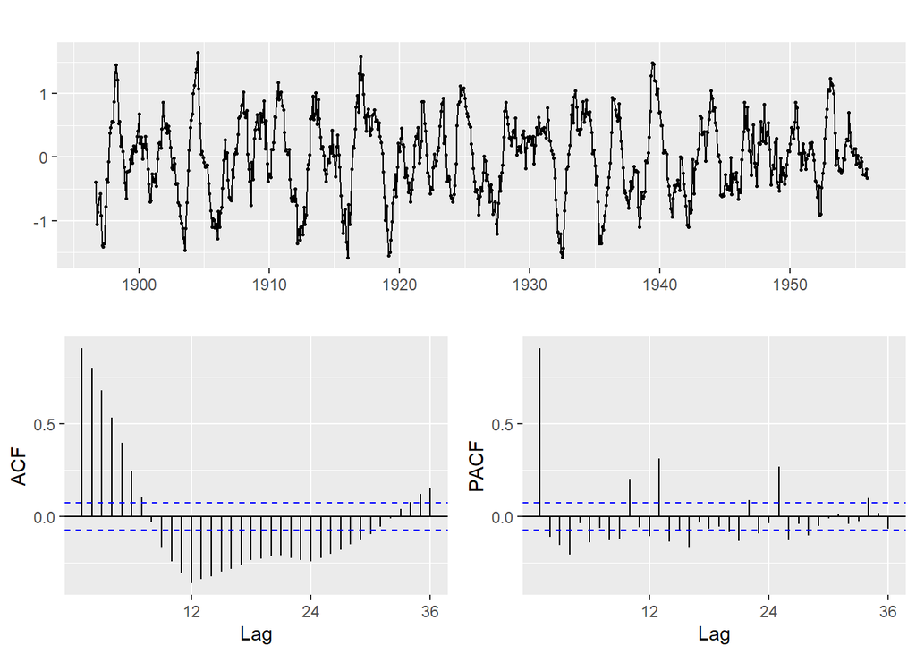

```r
datalog12 <- logD0TS2 %>% diff(lag=12)
datalog12 %>% ggtsdisplay()
```

```r
adf.test(datalog12)
```

```
##
##  Augmented Dickey-Fuller Test
##
## data:  datalog12
## Dickey-Fuller = -10.763, Lag order = 8, p-value = 0.01
## alternative hypothesis: stationary
```

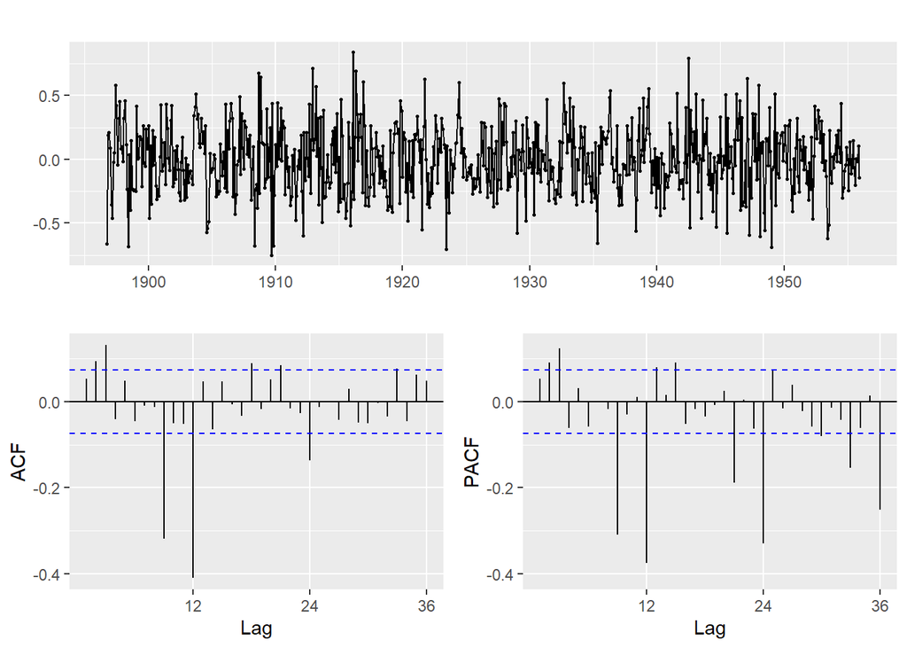

```r
datalog22 <- logD0TS2 %>% diff(lag=12) %>% diff()
datalog22 %>% ggtsdisplay()
```

```r
adf.test(datalog22)
```

```
##
##  Augmented Dickey-Fuller Test
##
## data:  datalog22
## Dickey-Fuller = -11.944, Lag order = 8, p-value = 0.01
## alternative hypothesis: stationary
```

```r
log1_2 <- Arima(logD0TS2, order=c(2, 0, 1), seasonal=c(2,0,0))
log2_2 <- Arima(logD0TS2, order=c(1, 0, 1), seasonal=c(1,0,0))
log3_2 <- Arima(logD0TS2, order=c(2, 0, 1), seasonal=c(1,0,0))
log4_2 <- Arima(logD0TS2, order=c(1, 0, 2), seasonal=c(1,0,0))
log5_2 <- Arima(logD0TS2, order=c(2, 0, 2), seasonal=c(1,0,0))
log6_2 <- Arima(logD0TS2, order=c(1, 0, 1), seasonal=c(1,0,1))
log7_2 <- Arima(logD0TS2, order=c(2, 0, 1), seasonal=c(1,0,1))
log8_2 <- Arima(logD0TS2, order=c(1, 0, 2), seasonal=c(1,0,1))
log9_2 <- Arima(logD0TS2, order=c(2, 0, 2), seasonal=c(1,0,1))
log10_2 <- Arima(logD0TS2, order=c(1, 0, 1), seasonal=c(2,0,1))
log11_2 <- Arima(logD0TS2, order=c(2, 0, 1), seasonal=c(2,0,1))
log12_2 <- Arima(logD0TS2, order=c(1, 0, 2), seasonal=c(2,0,1))
log12_2 <- Arima(logD0TS2, order=c(2, 0, 2), seasonal=c(2,0,1))
```

```r
getAIC <- function(fit) {
  c(fit$aic, fit$aicc, fit$bic)
}

tab2 <- rbind(getAIC(log1_2), getAIC(log2_2), getAIC(log3_2),getAIC(log4_2), getAIC(log5_2), getAIC(log6_2), getAIC(log7_2), getAIC(log8_2), getAIC(log9_2), getAIC(log10_2), getAIC(log11_2), getAIC(log12_2))
colnames(tab2) <- c("AIC", "AICc", "BIC")
rownames(tab2) <- c("SARIMA(2,0,1)(2,0,0)","SARIMA(1,0,1)(1,0,0)","SARIMA(2,0,1)(1,0,0)","SARIMA(1,0,2)(1,0,0)",
                   "SARIMA(2,0,2)(1,0,0)","SARIMA(1,0,1)(1,0,1)","SARIMA(2,0,1)(1,0,1)","SARIMA(1,0,2)(1,0,1)",
                   "SARIMA(2,0,2)(1,0,1)","SARIMA(1,0,1)(2,0,1)","SARIMA(1,0,2)(2,0,1)","SARIMA(2,0,2)(2,0,1)")
```

```r
tab2 %>% kableExtra::kbl() %>%
  kable_material(c("striped", "hover"))
```

[output not shown]

```r
log1_2
```

```
## Series: logD0TS2
## ARIMA(2,0,1)(2,0,0)[12] with non-zero mean
##
## Coefficients:
##          ar1      ar2      ma1    sar1     sar2    mean
##       1.7057  -0.7461  -0.6995  0.0971  -0.1062  3.3828
## s.e.  0.0852   0.0761   0.0987  0.0398   0.0375  0.0507
##
## sigma^2 = 0.03475:  log likelihood = 190.72
## AIC=-367.44   AICc=-367.29   BIC=-335.35
```

$$Y_t = (\phi_1+\phi_2)Y_{t-1} + \phi_1\phi_2Y_{t-2} + (\Phi_1+\Phi_2)Y_{t-12} + (\phi_1+\phi_2)(\Phi_1+\Phi_2)Y_{t-13} + \phi_1\phi_2(\Phi_1+\Phi_2)Y_{t-14} + \Phi_1\Phi_2Y_{t-24} + \Phi_1\Phi_2(\phi_1+\phi_2)Y_{t-25} + \Phi_1\Phi_2\phi_1\phi_2Y_{t-26}+ \varepsilon_t + \theta_1\varepsilon_{t-1}$$
$$Y_t = 0.96Y_{t-1} -1.273Y_{t-2} -0.009Y_{t-12} -0.009Y_{t-13} + 0.012Y_{t-14} -0.01Y_{t-24} -0.01Y_{t-25} + 0.013Y_{t-26}+ \varepsilon_t -0.7\varepsilon_{t-1}$$

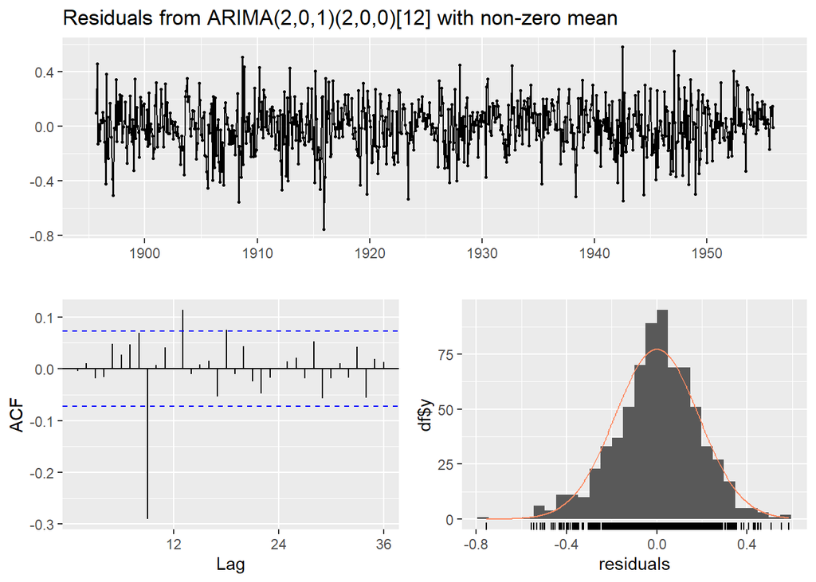

```
##
##  Ljung-Box test
##
## data:  Residuals from ARIMA(2,0,1)(2,0,0)[12] with non-zero mean
## Q* = 91.118, df = 18, p-value = 9.09e-12
##
## Model df: 6.   Total lags used: 24
```

```r
checkresiduals(log1_2)
```

```r
Box.test(residuals(log1_2), lag=4, type="Ljung-Box", fitdf=1)
```

```
##
##  Box-Ljung test
##
## data:  residuals(log1_2)
## X-squared = 0.52556, df = 3, p-value = 0.9132
```

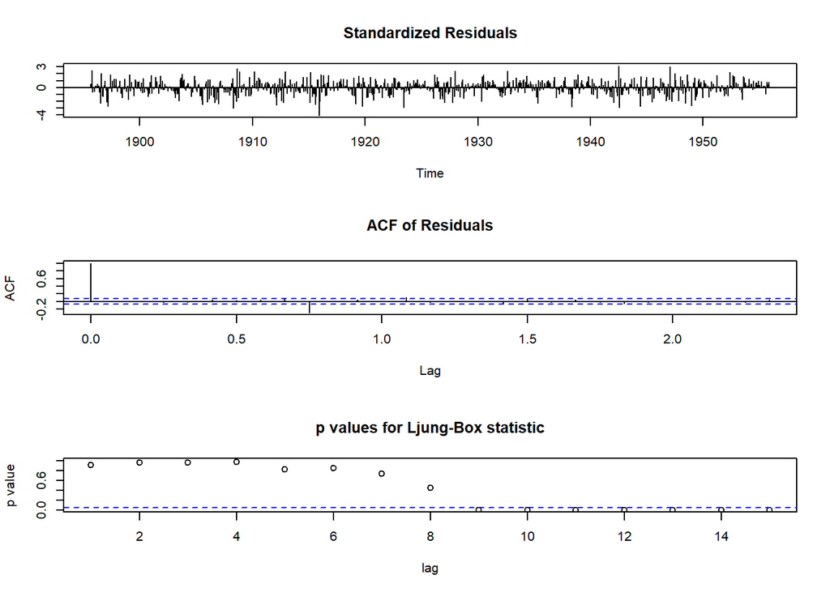

```r
tsdiag(log1_2, gof.lag = 15, omit.initial=F)
```

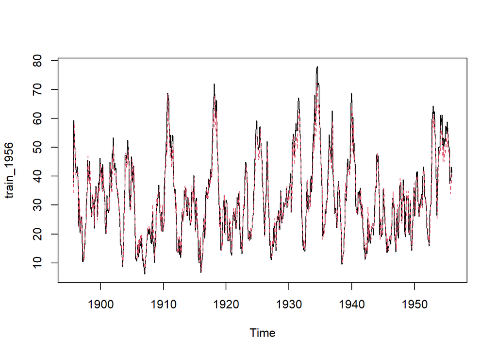

```
## integer(0)
```

```r
residualslog2 <- residuals(log1_2)
fittedlog2 <- logD0TS2 - residualslog2
ts.plot(train_1956) + points(exp(fittedlog2), type = "l", col = 2, lty = 2)
```

```r
forecastlog2 <- forecast(log1_2, h=12)
forecastlog2$lower <- exp(forecastlog2$lower)
forecastlog2$upper <- exp(forecastlog2$upper)
forecastlog2$mean <- exp(forecastlog2$mean)
forecastlog2$x <- exp(forecastlog2$x)
```

```r
drought.predict.test2 <- ts_reshape(val_1956)
colnames(drought.predict.test2)[2] <- "Actual"

forecast.full2 <- cbind(forecastlog2,drought.predict.test2[c("Actual")])
forecast.full2
```

```
##          Point Forecast    Lo 80    Hi 80    Lo 95    Hi 95 Actual
## Jan 1956       39.28583 30.93697 49.88777 27.26161 56.61355   43.1
## Feb 1956       36.48183 25.99487 51.19947 21.72554 61.26079   43.3
## Mar 1956       35.33844 23.43869 53.27965 18.85991 66.21481   46.8
## Apr 1956       33.52113 21.07858 53.30844 16.48867 68.14778   55.2
## May 1956       32.09739 19.40177 53.10043 14.86300 69.31590   57.5
## Jun 1956       31.60002 18.56161 53.79714 14.00534 71.29863   60.0
## Jul 1956       30.56017 17.59197 53.08809 13.13259 71.11502   55.8
## Aug 1956       29.33028 16.65387 51.65559 12.34230 69.70060   55.9
## Sep 1956       28.82132 16.21951 51.21416 11.96375 69.43216   57.4
## Oct 1956       28.37819 15.88263 50.70455 11.68124 68.94148   60.6
## Nov 1956       28.39652 15.84280 50.89771 11.63249 69.31986   69.3
## Dec 1956       27.78063 15.47360 49.87616 11.35147 67.98802   67.2
```

```r
acc2 <- accuracy(forecastlog2,val_1956)
acc2
```

```
##                    ME     RMSE      MAE      MPE     MAPE     MASE      ACF1
## Training set 29.22801 32.37700 29.22801 87.86432 87.86432 1.919703 0.9235952
## Test set     24.20902 26.67582 24.20902 41.10654 41.10654 1.590054 0.6973421
##              Theil's U
## Training set        NA
## Test set      5.894764
```

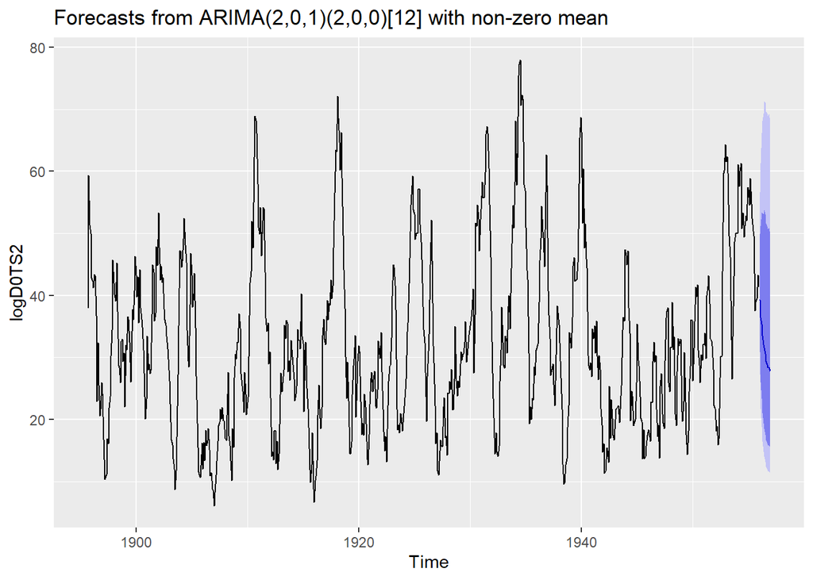

```r
autoplot(forecastlog2)
```

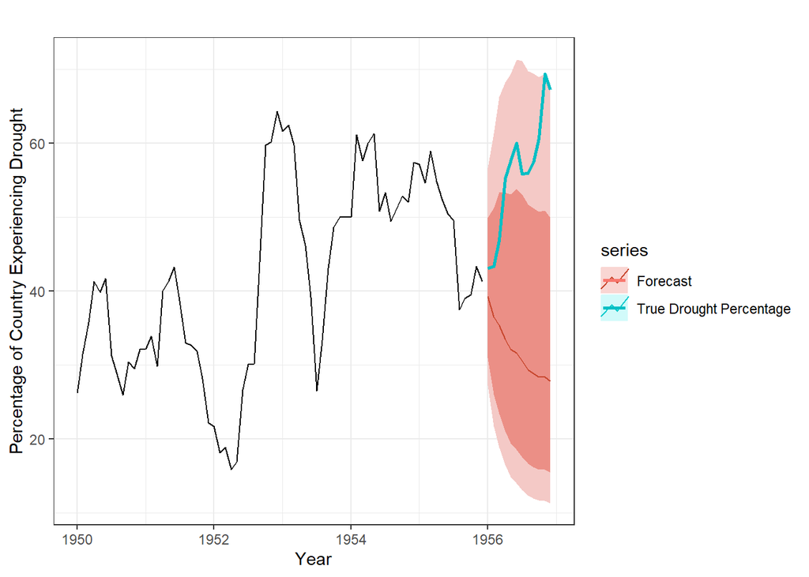

```r
autoplot(window(train_1956, start=c(1950,1))) +
  autolayer(forecastlog2, PI=TRUE, series="Forecast") +
  autolayer(val_1956, series="True Drought Percentage", size=1) +
  labs(x="Year", y="Percentage of Country Experiencing Drought") +
  theme_bw()
```

```r
auto.arima(logD0TS2)
```

```
## Series: logD0TS2
## ARIMA(2,0,1)(2,0,0)[12] with non-zero mean
##
## Coefficients:
##          ar1      ar2      ma1    sar1     sar2    mean
##       1.7057  -0.7461  -0.6995  0.0971  -0.1062  3.3828
## s.e.  0.0852   0.0761   0.0987  0.0398   0.0375  0.0507
##
## sigma^2 = 0.03475:  log likelihood = 190.72
## AIC=-367.44   AICc=-367.29   BIC=-335.35
```

# 7 Final Model Selection

## 7.1 Old Data

### 7.1.1 Models Selected

Holt Winters: D0.for.hw.old Cosine-Sine Model: d0_1.new SARIMA: forecastlog2

### 7.1.2 Model Comparison Table

```r
tab <- rbind(accuracy(D0.for.hw.old, val_1956)[2,2:3],
             accuracy(d0_1.validation, val_1956)[2,2:3],
             accuracy(forecastlog2, val_1956)[2,2:3])
rownames(tab) <- c("Full Holt Winters", "Cosine-sine", "SARIMA")
kable(tab)
```

|  | RMSE | MAE |
| --- | --- | --- |
| Full Holt Winters | 15.68956 | 13.89157 |
| Cosine-sine | 16.18810 | 14.15538 |
| SARIMA | 26.67582 | 24.20902 |

### 7.1.3 Visual Model Comparison

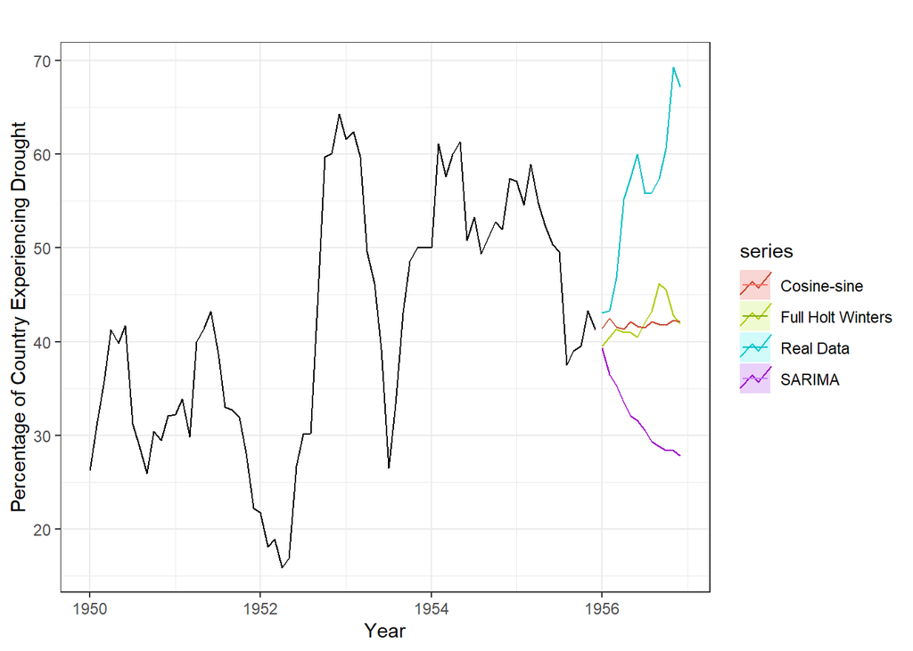

```r
autoplot(window(D0TS.train.old, start=c(1950,1))) +
  autolayer(D0.for.hw.old, PI=FALSE, series="Full Holt Winters") +
  autolayer(d0_1.validation, PI=FALSE, series="Cosine-sine") +
  autolayer(forecastlog2, PI=FALSE, series="SARIMA") +
  autolayer(D0TS.test.old, series="Real Data") +
  labs(x="Year", y="Percentage of Country Experiencing Drought") +
  theme_bw()
```

### 7.1.4 Selection

From a combination of RMSE and MAE, we select the Full Holt Winters model for the overall period from 1895 to 1956.

```r
oldModel <- autoplot(window(D0TS.train.old, start=c(1950,1))) +
  autolayer(D0.for.hw.old, PI=TRUE, series="Full Holt Winters") +
  autolayer(D0TS.test.old, series="Real Data") +
  labs(x="Year", y="Percentage of Country Experiencing Drought", title = "Old Model") +
  theme_bw()
```

## 7.2 New Data

### 7.2.1 Models Selected

Holt Winters: D0.for.season.new Cosine-Sine Model: d0_2.new SARIMA: forecastlog

### 7.2.2 Model Comparison Table

```r
tab <- rbind(accuracy(D0.for.season.new, val_2022)[2,2:3],
             accuracy(d0_2.validation2, val_2022)[2,2:3],
             accuracy(forecastlog, val_2022)[2,2:3])
rownames(tab) <- c("Holt Season", "Cosine-sine", "SARIMA")
kable(tab)
```

|  | RMSE | MAE |
| --- | --- | --- |
| Holt Season | 17.00088 | 15.34621 |
| Cosine-sine | 16.71857 | 14.95651 |
| SARIMA | 11.86539 | 11.15885 |

### 7.2.3 Visual Model Comparison

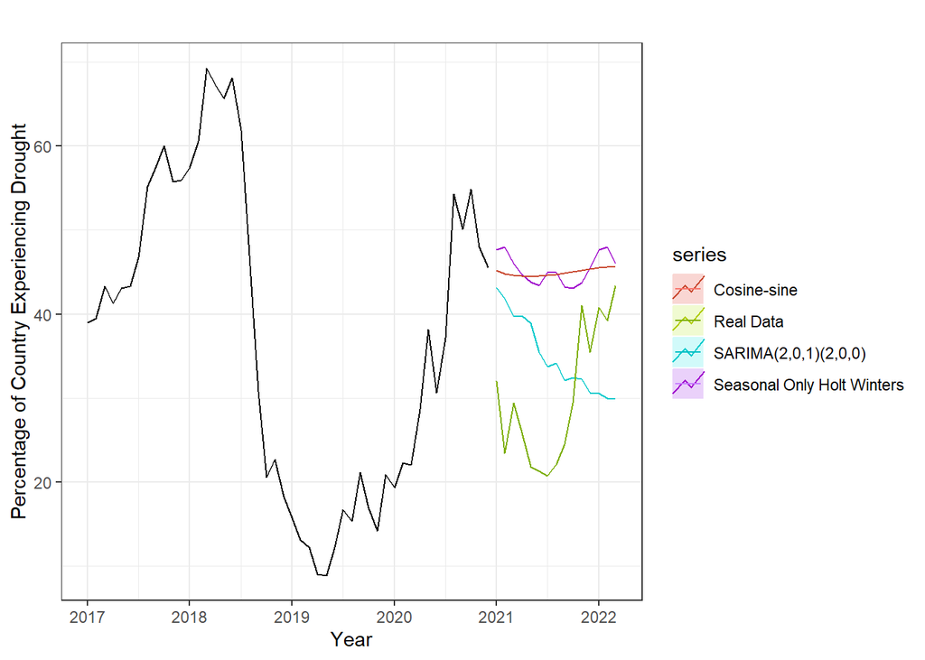

```r
autoplot(window(D0TS.train.new, start=c(2017,1))) +
  autolayer(D0.for.season.new, PI=FALSE, series="Seasonal Only Holt Winters") +
  autolayer(d0_2.validation2, PI=FALSE, series="Cosine-sine") +
  autolayer(forecastlog, PI=FALSE, series="SARIMA(2,0,1)(2,0,0)") +
  autolayer(D0TS.test.new, series="Real Data") +
  labs(x="Year", y="Percentage of Country Experiencing Drought") +
  theme_bw()
```

### 7.2.4 Selection

From a combination of RMSE and MAE, we select the SARIMA model for the overall period from 1956 to 2022.

```r
newModel <- autoplot(window(D0TS.train.new, start=c(2017,1))) +
  autolayer(forecastlog, PI=TRUE, series="SARIMA") +
  autolayer(D0TS.test.new, series="Real Data") +
  labs(x="Year", y="Percentage of Country Experiencing Drought", title = "New Model") +
  theme_bw()
```

# 8 Final Comparison

## 8.1 Old vs New Visual

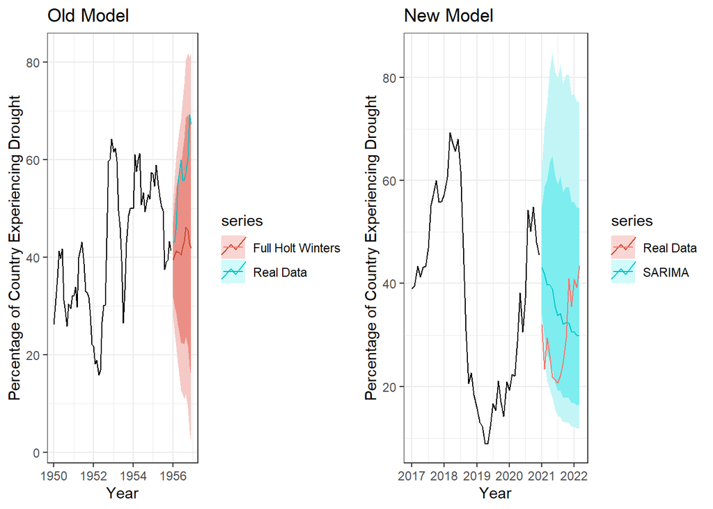

```r
grid.arrange(oldModel, newModel, ncol = 2)
```

## 8.2 Old vs New Mathematical

```r
val.1956 <- ts_reshape(val_1956)[,-3]
#val.1956[1:12,] <- c(1,2,3,107.6,107.5,113.2)

retail.full <- cbind(D0.for.hw.old, val.1956[c("1956")])
colnames(retail.full)[6] <- "Actual"
retail.full
```

```
##          Point Forecast    Lo 80    Hi 80     Lo 95    Hi 95 Actual
## Jan 1956       39.51370 31.77099 47.25640 27.672245 51.35514   43.1
## Feb 1956       40.48496 29.91094 51.05898 24.313392 56.65653   43.3
## Mar 1956       41.30807 28.47475 54.14139 21.681204 60.93494   46.8
## Apr 1956       40.98476 26.19923 55.77030 18.372237 63.59729   55.2
## May 1956       40.96702 24.42696 57.50709 15.671173 66.26288   57.5
## Jun 1956       40.49543 22.34083 58.65003 12.730370 68.26050   60.0
## Jul 1956       42.07521 22.41131 61.73911 12.001873 72.14855   55.8
## Aug 1956       43.23058 22.13977 64.32138 10.974971 75.48618   55.9
## Sep 1956       46.17256 23.72130 68.62383 11.836319 80.50881   57.4
## Oct 1956       45.50893 21.75203 69.26582  9.175886 81.84196   60.6
## Nov 1956       42.75385 17.73736 67.77034  4.494425 81.01327   69.3
## Dec 1956       41.90612 15.66924 68.14299  1.780281 82.03195   67.2
```

```r
val.2022 <- ts_reshape(val_2022)[,-3]
val.2022[13:15,] <- c(c(0,0),c(0,0),c(0,0)) #This is really dumb
#val.1956[1:12,] <- c(1,2,3,107.6,107.5,113.2)

retail.full2 <- cbind(forecastlog, val.2022)
colnames(retail.full2)[6] <- "Actual"
head(retail.full2,12)
```

```
##          Point Forecast    Lo 80    Hi 80    Lo 95    Hi 95 Actual 2021
## Jan 2021       43.13632 33.96058 54.79125 29.92200 62.18643      1 32.0
## Feb 2021       41.84372 29.77813 58.79810 24.87095 70.39930      2 23.4
## Mar 2021       39.75315 26.29289 60.10420 21.12512 74.80729      3 29.4
## Apr 2021       39.77482 24.89371 63.55165 19.42465 81.44475      4 25.9
## May 2021       38.90306 23.35835 64.79261 17.83056 84.87945      5 21.8
## Jun 2021       35.50280 20.67467 60.96583 15.52853 81.16986      6 21.3
## Jul 2021       33.74954 19.22781 59.23875 14.27529 79.79039      7 20.7
## Aug 2021       34.14655 19.16174 60.84974 14.11270 82.61967      8 22.1
## Sep 2021       32.08098 17.82340 57.74372 13.05767 78.81878      9 24.5
## Oct 2021       32.47324 17.92878 58.81669 13.09142 80.54977     10 29.4
## Nov 2021       32.29452 17.76522 58.70664 12.94698 80.55437     11 41.0
## Dec 2021       30.63198 16.81820 55.79184 12.24431 76.63300     12 35.5
```